# INNDL_Project_1

**1. Data import and Understanding [10 Marks]**

A. Read the ‘Signals.csv’ as DatFrame and import required libraries. [2 Marks]

```python
# Importing required libraries
import numpy as np
import pandas as pd
import matplotlib.pyplot as plt
import seaborn as sns
%matplotlib inline
import warnings
warnings.filterwarnings('ignore')
%tensorflow_version 2.x
import tensorflow as tf
print(tf.__version__)
tf.random.set_seed(42) #Setting random seed
```

```
2.7.0
```

```python
#Mounting Google Drive
from google.colab import drive
drive.mount('/content/drive')
```

```python
# Reading Signals.csv as a dataframe
df = pd.read_csv('/content/drive/MyDrive/GL/Projects/Deep Learning Project 1/Signal.csv')
```

```python
df.head()
```

|  | Parameter 1 | Parameter 2 | Parameter 3 | Parameter 4 | Parameter 5 | Parameter 6 | Parameter 7 | Parameter 8 | Parameter 9 | Parameter 10 | Parameter 11 | Signal_Strength |
| --- | --- | --- | --- | --- | --- | --- | --- | --- | --- | --- | --- | --- |
| 0 | 7.4 | 0.70 | 0.00 | 1.9 | 0.076 | 11.0 | 34.0 | 0.9978 | 3.51 | 0.56 | 9.4 | 5 |
| 1 | 7.8 | 0.88 | 0.00 | 2.6 | 0.098 | 25.0 | 67.0 | 0.9968 | 3.20 | 0.68 | 9.8 | 5 |
| 2 | 7.8 | 0.76 | 0.04 | 2.3 | 0.092 | 15.0 | 54.0 | 0.9970 | 3.26 | 0.65 | 9.8 | 5 |
| 3 | 11.2 | 0.28 | 0.56 | 1.9 | 0.075 | 17.0 | 60.0 | 0.9980 | 3.16 | 0.58 | 9.8 | 6 |
| 4 | 7.4 | 0.70 | 0.00 | 1.9 | 0.076 | 11.0 | 34.0 | 0.9978 | 3.51 | 0.56 | 9.4 | 5 |

```python
df.info()
```

```
<class 'pandas.core.frame.DataFrame'>
RangeIndex: 1599 entries, 0 to 1598
Data columns (total 12 columns):
 #   Column           Non-Null Count  Dtype
---  ------           --------------  -----
 0   Parameter 1      1599 non-null   float64
 1   Parameter 2      1599 non-null   float64
 2   Parameter 3      1599 non-null   float64
 3   Parameter 4      1599 non-null   float64
 4   Parameter 5      1599 non-null   float64
 5   Parameter 6      1599 non-null   float64
 6   Parameter 7      1599 non-null   float64
 7   Parameter 8      1599 non-null   float64
 8   Parameter 9      1599 non-null   float64
 9   Parameter 10     1599 non-null   float64
 10  Parameter 11     1599 non-null   float64
 11  Signal_Strength  1599 non-null   int64
dtypes: float64(11), int64(1)
memory usage: 150.0 KB
```

```python
# The dataframe has 12 columns and 1599 rows
```

```python
df.describe()
```

|  | Parameter 1 | Parameter 2 | Parameter 3 | Parameter 4 | Parameter 5 | Parameter 6 | Parameter 7 | Parameter 8 | Parameter 9 | Parameter 10 | Parameter 11 | Signal_Strength |
| --- | --- | --- | --- | --- | --- | --- | --- | --- | --- | --- | --- | --- |
| count | 1599.000000 | 1599.000000 | 1599.000000 | 1599.000000 | 1599.000000 | 1599.000000 | 1599.000000 | 1599.000000 | 1599.000000 | 1599.000000 | 1599.000000 | 1599.000000 |
| mean | 8.319637 | 0.527821 | 0.270976 | 2.538806 | 0.087467 | 15.874922 | 46.467792 | 0.996747 | 3.311113 | 0.658149 | 10.422983 | 5.636023 |
| std | 1.741096 | 0.179060 | 0.194801 | 1.409928 | 0.047065 | 10.460157 | 32.895324 | 0.001887 | 0.154386 | 0.169507 | 1.065668 | 0.807569 |
| min | 4.600000 | 0.120000 | 0.000000 | 0.900000 | 0.012000 | 1.000000 | 6.000000 | 0.990070 | 2.740000 | 0.330000 | 8.400000 | 3.000000 |
| 25% | 7.100000 | 0.390000 | 0.090000 | 1.900000 | 0.070000 | 7.000000 | 22.000000 | 0.995600 | 3.210000 | 0.550000 | 9.500000 | 5.000000 |
| 50% | 7.900000 | 0.520000 | 0.260000 | 2.200000 | 0.079000 | 14.000000 | 38.000000 | 0.996750 | 3.310000 | 0.620000 | 10.200000 | 6.000000 |
| 75% | 9.200000 | 0.640000 | 0.420000 | 2.600000 | 0.090000 | 21.000000 | 62.000000 | 0.997835 | 3.400000 | 0.730000 | 11.100000 | 6.000000 |
| max | 15.900000 | 1.580000 | 1.000000 | 15.500000 | 0.611000 | 72.000000 | 289.000000 | 1.003690 | 4.010000 | 2.000000 | 14.900000 | 8.000000 |

```python
# Signal_Strength, which is the target variable, ranges from 3 to 8 in the dataset
# There is no significant skew in the target variable (mean and median are not much different from each other)
```

B. Check for missing values and print percentage for each attribute. [2 Marks]

```python
df.isnull().sum()*100/df.shape[0]
```

```
Parameter 1        0.0
Parameter 2        0.0
Parameter 3        0.0
Parameter 4        0.0
Parameter 5        0.0
Parameter 6        0.0
Parameter 7        0.0
Parameter 8        0.0
Parameter 9        0.0
Parameter 10       0.0
Parameter 11       0.0
Signal_Strength    0.0
dtype: float64
```

```python
# There is no missing value
```

C. Check for presence of duplicate records in the dataset and impute with appropriate method. [2 Marks]

```python
#Checking for duplicates
dups = df.duplicated()
print(dups.sum())
```

```
240
```

```python
# There are 240 duplicate rows in the dataframe
```

```python
#Dropping duplicates based on all columns and retaining only the first row
df.drop_duplicates(subset = None, keep='first', inplace=True)
```

```python
#Checking for duplicates again
dups1 = df.duplicated()
print(dups1.sum())
```

```
0
```

```python
#Checking shape of the dataset
df.shape
```

```
(1359, 12)
```

D. Visualise distribution of the target variable. [2 Marks]

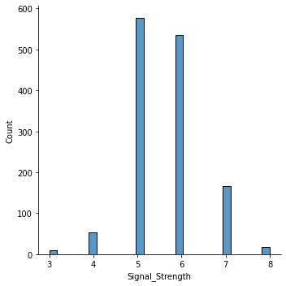

```python
# Visualizing the distribution of the target variable using Seaborn Displot
sns.displot(x='Signal_Strength', data=df)
```

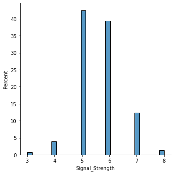

```python
# Checking the percentage-wise distribution
sns.displot(x='Signal_Strength', data=df, stat='percent')
```

E. Share insights from the initial data analysis (at least 2). [2 Marks]

```python
# There are 11 input variables (Parameter 1 to Parameter 11) and 1 target variable (Signal_Strength)
# Signal_Strength values range from 3 to 8 in the dataset
# There is no significant skew in Signal_Strength values (mean and median are quite close to each other)
# From the distribution plots, it can be seen that, most of the samples (over 80%) have signal strength 5 or 6
# The distribution roughly resembles a normal distribution (bell curve)
```

**2. Data preprocessing [7 Marks]**

A. Split the data into X & Y. [1 Marks]

```python
Y = df['Signal_Strength']
```

```python
Y.shape
```

```
(1359,)
```

```python
X = df.drop(['Signal_Strength'], axis=1)
```

```python
X.shape
```

```
(1359, 11)
```

B. Split the data into train & test with 70:30 proportion.[1 Marks]

```python
from sklearn.model_selection import train_test_split
X_train, X_test, Y_train, Y_test = train_test_split(X, Y, test_size=0.3, random_state=42)
```

C. Print shape of all the 4 variables and verify if train and test data is in sync. [1 Marks]

```python
X_train.shape
```

```
(951, 11)
```

```python
X_test.shape
```

```
(408, 11)
```

```python
Y_train.shape
```

```
(951,)
```

```python
Y_test.shape
```

```
(408,)
```

```python
# Based on the test_size of 30% given, the data has been split into 951 samples for training and 408 for testing
# The shape of the 4 variables indicate that the train and test data are in sync
```

D. Normalise the train and test data with appropriate method. [2 Marks]

```python
# Normalizing the data using StandardScaler from Scikit-learn
from sklearn.preprocessing import StandardScaler
sc = StandardScaler()
X_train = sc.fit_transform(X_train)
X_test = sc.transform(X_test) # Here we do not fit again as we want to use the same scaling used on X_train. Hence only transform is used.
```

```python
X_train, X_test
```

```
(array([[ 3.31616196, -0.67010558,  1.8291926 , ..., -1.99985681,
          0.90236307,  0.35241996],
        [ 0.51968377, -0.387402  , -0.21861594, ..., -1.0626813 ,
         -0.86300883, -0.9398189 ],
        [ 2.44226252, -0.387402  ,  1.8291926 , ..., -2.13373903,
          1.25543745, -0.2013967 ],
        ...,
        [-0.87855533, -0.33086129, -0.98654415, ..., -0.05856467,
         -0.03916861, -0.75521335],
        [ 0.34490388, -1.17897203,  0.19094577, ..., -0.92879908,
         -0.62762591, -0.01679115],
        [ 0.4614238 , -1.06589059,  0.75409311, ..., -0.86185797,
         -0.62762591,  0.90623661]]),
 array([[-0.35421567,  0.51724945, -1.191325  , ...,  0.20919976,
         -0.74531737, -0.84751613],
        [-0.06291586,  0.60206053, -0.88415372, ..., -0.12550578,
          0.54928869,  0.44472273],
        [ 0.05360407, -0.89626845,  0.80528833, ..., -0.92879908,
          0.90236307,  0.72163106],
        ...,
        [ 0.34490388,  0.3476273 ,  0.60050747, ...,  0.41002309,
         -0.45108872, -0.10909392],
        [ 0.9275035 , -1.17897203,  1.4708261 , ..., -1.0626813 ,
          0.43159723,  0.90623661],
        [ 1.04402343, -1.23551274,  0.39572662, ..., -0.46021132,
          1.02005453,  0.72163106]]))
```

E. Transform Labels into format acceptable by Neural Network [2 Marks]

```python
#Converting Signal Strength values to 6 classes from 0 to 5 by substracting each value by 3
#Signal strength 3 = class 0, 4 = class 1, 5 = class 2, 6 = class 3, 7 = class 4 & 8 = class 5
Y_train = Y_train-3
Y_test = Y_test-3
Y_train.unique(), Y_test.unique()
```

```
(array([3, 2, 1, 4, 5, 0]), array([2, 3, 4, 1, 0, 5]))
```

```python
Y_train, Y_test
```

```
(374     3
 1225    2
 363     2
 1426    3
 89      2
        ..
 1285    2
 1329    3
 1526    3
 1011    3
 1322    2
 Name: Signal_Strength, Length: 951, dtype: int64, 55      2
 1291    3
 1544    4
 593     2
 1261    1
        ..
 1305    2
 1120    5
 456     2
 1076    3
 838     4
 Name: Signal_Strength, Length: 408, dtype: int64)
```

```python
# One hot encoding the classes
Y_train = tf.keras.utils.to_categorical(Y_train, num_classes=6)
Y_test = tf.keras.utils.to_categorical(Y_test, num_classes=6)

Y_train, Y_test
```

```
(array([[0., 0., 0., 1., 0., 0.],
        [0., 0., 1., 0., 0., 0.],
        [0., 0., 1., 0., 0., 0.],
        ...,
        [0., 0., 0., 1., 0., 0.],
        [0., 0., 0., 1., 0., 0.],
        [0., 0., 1., 0., 0., 0.]], dtype=float32),
 array([[0., 0., 1., 0., 0., 0.],
        [0., 0., 0., 1., 0., 0.],
        [0., 0., 0., 0., 1., 0.],
        ...,
        [0., 0., 1., 0., 0., 0.],
        [0., 0., 0., 1., 0., 0.],
        [0., 0., 0., 0., 1., 0.]], dtype=float32))
```

**3. Model Training & Evaluation using Neural Network [13 Marks]**

A. Design a Neural Network to train a classifier. [3 Marks]

```python
# Defining a sequential model
model = tf.keras.models.Sequential()
# Adding a dense(fully connected) layer with softmax as activation function (as this is multi-class classification)
model.add(tf.keras.layers.Dense(6, input_shape=(11,), activation='softmax'))
# Compiling the model using SGD optimizer, categorical crossentropy loss function and accuracy as metric
model.compile(optimizer='sgd', loss='categorical_crossentropy', metrics=['accuracy'])
model.summary()
```

```
Model: "sequential"
_________________________________________________________________
 Layer (type)                Output Shape              Param #
=================================================================
 dense (Dense)               (None, 6)                 72

=================================================================
Total params: 72
Trainable params: 72
Non-trainable params: 0
_________________________________________________________________
```

```python
# The model has 66 weights (11 input features * 6 outputs) and 6 bias (1 for each output) leading to a total of 72 parameters (66 + 6)
```

B. Train the classifier using previously designed Architecture [2 Marks]

```python
# Training the model with 100 epochs (cycles)
nn_model = model.fit(X_train, Y_train, validation_data=(X_test, Y_test), epochs=100)
```

```python
# The final validation accuracy of the model after 100 epochs is 0.6078 and final validation loss is 0.9539
```

C. Plot 2 separate visuals. [3 Marks]

i. Training Loss and Validation Loss

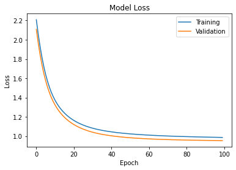

```python
# Plotting the training and validation losses against the number of Epochs
plt.plot(nn_model.history['loss'])
plt.plot(nn_model.history['val_loss'])
plt.title('Model Loss')
plt.ylabel('Loss')
plt.xlabel('Epoch')
plt.legend(['Training', 'Validation'])
plt.show()
```

ii. Training Accuracy and Validation Accuracy

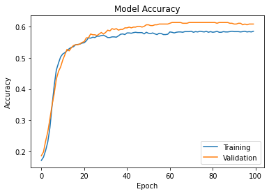

```python
# Plotting the training and validation accuracies against the number of Epochs
plt.plot(nn_model.history['accuracy'])
plt.plot(nn_model.history['val_accuracy'])
plt.title('Model Accuracy')
plt.ylabel('Accuracy')
plt.xlabel('Epoch')
plt.legend(['Training', 'Validation'])
plt.show()
```

D. Design new architecture/update existing architecture in attempt to improve the performance of the model. [2 Marks]

```python
# Defining a new sequential model
new_model = tf.keras.models.Sequential()

# Adding a dense(fully connected) iput layer with relu (Rectified Linear Unit) activation function with 10 nodes/neurons
new_model.add(tf.keras.layers.Dense(10, input_shape=(11,), activation='relu'))
# Adding another dense layer with relu activation function with 8 nodes
new_model.add(tf.keras.layers.Dense(8, activation='relu'))
# Adding a dense output layer with softmax activation function with 6 nodes to match the 6 outputs required
new_model.add(tf.keras.layers.Dense(6, activation='softmax'))
# The above neural network architecture was come up after multiple trials and errors with different activation functions including sigmoid and tanh and different number of nodes based on resulting loss and accuracy

# Tweaking the SGD optimizer to get best possible results (using trial and error)
from tensorflow.keras.optimizers import SGD
opt = SGD(lr=0.003, momentum=0.9, nesterov=True)

# Compiling the model using the tweaked SGD optimizer, categorical crossentropy loss function and accuracy as metric
new_model.compile(optimizer=opt, loss='categorical_crossentropy', metrics=['accuracy'])
new_model.summary()
```

```
Model: "sequential_6"
_________________________________________________________________
 Layer (type)                Output Shape              Param #
=================================================================
 dense_16 (Dense)            (None, 10)                120

 dense_17 (Dense)            (None, 8)                 88

 dense_18 (Dense)            (None, 6)                 54

=================================================================
Total params: 262
Trainable params: 262
Non-trainable params: 0
_________________________________________________________________
```

```python
# Training the new model
new_nn_model = new_model.fit(X_train, Y_train, validation_data=(X_test, Y_test), epochs=100)
```

E. Plot visuals as in Q3.C and share insights about difference observed in both the models. [3 Marks]

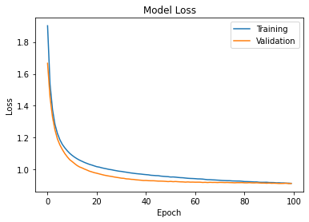

```python
# Plotting the training and validation losses against the number of Epochs for the new model
plt.plot(new_nn_model.history['loss'])
plt.plot(new_nn_model.history['val_loss'])
plt.title('Model Loss')
plt.ylabel('Loss')
plt.xlabel('Epoch')
plt.legend(['Training', 'Validation'])
plt.show()
```

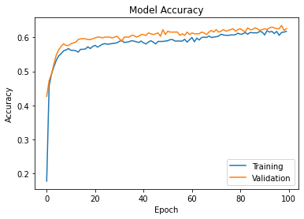

```python
# Plotting the training and validation accuracies against the number of Epochs for the new model
plt.plot(new_nn_model.history['accuracy'])
plt.plot(new_nn_model.history['val_accuracy'])
plt.title('Model Accuracy')
plt.ylabel('Accuracy')
plt.xlabel('Epoch')
plt.legend(['Training', 'Validation'])
plt.show()
```

```python
# Insights:
# It was possible to reduce the validation loss to 0.9132 in the new model compared to 0.9539 obtained in the previous model
# It was possible to improve the validation accuracy to 0.6250 in the new model compared to 0.6078 that we got in the previous model
# In the new model, a couple more dense layers were added with Rectified Linear Unit activation functions.
# This probably would have made the model's structure complex enough to better capture the actual relationship between the input variables and signal strength
# When even more layers and neurons were added to the model in the trial and error approach (not shown here), the model started to overfit and perform worse
# Other activation functions like sigmoid and tanh were also tried in the trial and error approach, but they did not improve the performance
# In the new model, the SGD optimizer was tweaked using the available hyperparameters (learning rate, momentum and enabling Nesterov accelerated gradient) to get the best possible performance
# Other optimizers including Adam optimizer were tried, but did not yield better results
# From the plots it is clear that both the models did not overfit (validation data performance was better than training data performance)
# It can also be seen from the plots that the convergence of accuracy and loss were steep till around the first 10-20 epochs after which they were relatively gradual
```